# Efficient Programming

R Programming 2025

Ella Kaye and Heather Turner

Department of Statistics, University of Warwick

March 25, 2025

## Overview

- Memory management
- Benchmarking
- Improving run time
- Parallelisation
- Outlook to package development

# Memory management

## Overview

Objects created in R are stored in memory. This has the advantage that objects can be accessed faster, but R slows down as the memory fills up. Creating objects also takes time.

Therefore:

- Re-use temporary variables. The allocated storage will be re-used if the vector has the same length.
- Save results for re-use, e.g. index variables
- Don’t save intermediate results unnecessarily – compute on-the-fly
- Remove large objects when no longer needed (with `rm()`)

## Basic data structures

Try to use the simplest data structure for your purpose

- matrices vs. data frames
- character or integer vectors vs. factors
- logical or integer vectors vs. numeric vectors
- unnamed objects vs. named objects

It is especially important to use low-level structures for computation

You can create richer objects as a final step before returning to the user.

## Big Data

Modern computers have enough RAM to work with millions of records using standard functions.

Some packages to work more efficiently with big data:

- **data.table** faster operations on data frames; read/write large CSVs
- **dplyr** + **dbplyr** processing of data in databases.
- **arrow** read/write large CSVs or binary files e.g. Parquet; processing larger-than-memory data with **dplyr** commands.
- **bigmemory**, **biganalytics** faster matrix operations, generalized linear models, kmeans

## Growing Objects

Adding to an object in a loop

```r
res <- NULL
for (i in 1:5000) res <- c(res, 1)
```

may force a copy to be made at each iteration, with each copy stored until the loop has completed.

It is **far better** to create an object of the necessary size first

```r
res <- numeric(5000)
for (i in seq_along(res)) res[i] <- 1
```

To initialise a list we can use

```r
res <- vector(mode = "list", length = 100)
```

## Copy-on-Change

R usually copies an object to make changes to it.

`tracemem` can be used to trace copies of an object

```r
z <- NULL
for (i in 1:3) {
  z <- c(z,1)
  print(tracemem(z))
}
```

```
[1] "<0x122220648>"
[1] "<0x11940ba08>"
[1] "<0x127b9b9c8>"
```

## Copy-on-change (pre-allocated)

```r
z <- numeric(2)
print(tracemem(z))
```

```
[1] "<0x167fb48c8>"
```

```r
for (i in 1:2) {
  z[i] <- i
  print(tracemem(z))
}
```

```
tracemem[0x167fb48c8 -> 0x167fa90c8]:
[1] "<0x167fa90c8>"
[1] "<0x167fa90c8>"
```

# Benchmarking

## Benchmarking

There will usually be many ways to write code for a given task. To compare alternatives, we can use benchmark the code.

If the code is more than a single expression, create wrappers for each alternative

```r
grow <- function(n){
  res <- NULL
  for (i in 1:n) res <- c(res, 1)
  res
}
pre_specify <- function(n){
  res <- numeric(n)
  for (i in seq_along(res)) res[i] <- 1
  res
}
```

## `bench::mark()`

Run the two alternatives with `bench::mark()`. This function

- Runs alternatives ≥ 1 time; at most enough times to take 0.5s
- Makes sure the two expressions return the same result!

```r
library(bench)
(bm <- bench::mark(grow(5000), pre_specify(5000)))
```

```
# A tibble: 2 × 6
  expression             min   median `itr/sec` mem_alloc `gc/sec`
  <bch:expr>        <bch:tm> <bch:tm>     <dbl> <bch:byt>    <dbl>
1 grow(5000)          26.9ms   29.8ms      33.1    95.6MB    60.4
2 pre_specify(5000)  100.3µs  108.4µs    8889.     55.7KB     8.00
```

- `GC` is the garbage collector which tidies up deleted objects
- `itr/sec` is how many times the expression could be run in 1s

## Plotting benchmarks

Distribution tends to be right-skewed - focus on the median!

```r
plot(bm)
```

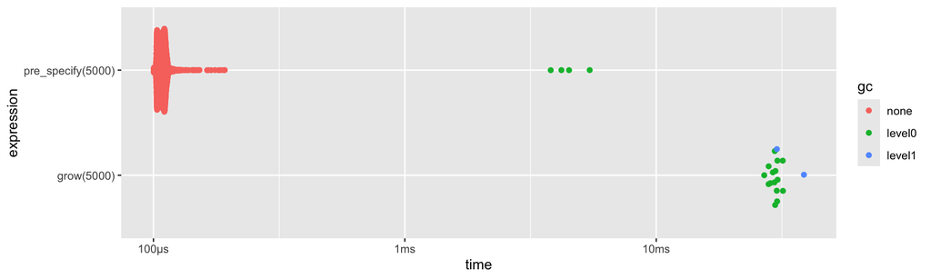

## Scaling

Benchmarking can be difficult as the best option can depend on the size of the data, e.g. memory allocation can overshadow run time for small objects.

When thinking about how our code scales to bigger, we need to consider what we mean by “big”

- number of rows or number of columns?
- number of observations or number of factor levels?

`bench::press()` compares a function over a grid of parameters

## `bench::press()`

```r
bench::press(n = c(10, 100, 1000), k = c(100, 10, 1),
  bench::mark(gl(n, k, length = 1000)) # `gl` generates factor levels
)
```

```
# A tibble: 9 × 8
  expression              n     k      min   median `itr/sec` mem_alloc `gc/sec`
  <bch:expr>          <dbl> <dbl> <bch:tm> <bch:tm>     <dbl> <bch:byt>    <dbl>
1 gl(n, k, length = …    10   100   6.31µs   7.22µs   132845.   15.91KB     13.3
2 gl(n, k, length = …   100   100  40.18µs  45.22µs    21975.    46.2KB     21.8
3 gl(n, k, length = …  1000   100 407.13µs 450.57µs     2229.  422.34KB     21.6
4 gl(n, k, length = …    10    10   3.24µs   3.73µs   256855.    4.39KB     25.7
5 gl(n, k, length = …   100    10   9.43µs  10.46µs    91904.   11.05KB     18.4
6 gl(n, k, length = …  1000    10 102.58µs 112.55µs     8879.   70.78KB     12.7
7 gl(n, k, length = …    10     1   2.99µs   3.32µs   284092.    3.95KB     28.4
8 gl(n, k, length = …   100     1   6.44µs   7.05µs   134715.    7.53KB     26.9
9 gl(n, k, length = …  1000     1  72.65µs  76.22µs    12946.   35.62KB     10.4
```

## Exercise 1

Suppose we have a matrix of data and a two-level factor

```r
nr <- 10
nc <- 50
X <- matrix(rnorm(nr * nc, 10, 3), nrow = nr)
grp <- gl(2, nc/2)
```

Use `bench::mark()` to compare the following ways to find the coefficients of a linear model fitted to each row

```r
# one
res <- vector("list", nr)
for(i in seq_len(nr)){
  res[[i]] <- coef(lm(X[i,] ~ grp))
}
do.call("cbind", res)
# two
res2 <- coef(lm(t(X) ~ grp))
```

# Improving run time

## Faster common operations

- Sorting
  - Use `sort(x, partial = 1:10)` to get the top 10
  - Use `sort(x, decreasing = TRUE)` vs `rev(sort(x))`
- Generating numeric vectors
  - `seq.int()`, `seq_along(x)`, `seq_len(n)` vs `seq()`
  - `rep.int()` or `rep_len(n)` vs `rep()`
- `which.min()`, `which.max()` vs e.g. `which(x == min(x))`
- `anyNA(x)` vs `any(is.na(x))`

## For loops

For loops are an intuitive way to write code, but can be very inefficient.

`for` is a function, `:` or `seq_along` is another function, each use of `[` is a call to a function, …, so a loop involves many nested function calls.

Try to keep for loops for truly iterative computations or tasks that are fast in any case (optimizing code takes time!)

Otherwise make loops as lean as possible, by pre-computing values that do not need be be computed iteratively.

## Vectorization

Vectorization is operating on vectors (or vector-like objects) rather than individual elements.

Many operations in R are vectorized, e.g.

```r
x <- 1:3
y <- 3:1
x == y
```

```
[1] FALSE  TRUE FALSE
```

```r
log(x)
```

```
[1] 0.0000000 0.6931472 1.0986123
```

```r
res <- list(a = 1:3, b = 1:6)
lengths(res)
```

```
a b
3 6
```

We do not need to loop through each element!

## Recycling

Vectorized functions will recycle shorter vectors to create vectors of the same length

```r
1:4 + 0:1 + 2 # 1+0+2, 2+1+2, 3+0+2, 4+1+2
```

```
[1] 3 5 5 7
```

This is particularly useful for single values

```r
cbind(1, 3:4)
```

```
     [,1] [,2]
[1,]    1    3
[2,]    1    4
```

and for generating regular patterns

```r
paste0(rep(1:3, each = 2), c("a", "b"))
```

```
[1] "1a" "1b" "2a" "2b" "3a" "3b"
```

## `ifelse()`

`ifelse` is a vectorised version of `if` and `else` blocks

```r
x <- c(5, 2, 9, 12)
ifelse(x < 6, 2 * x, 3 * x)
```

```
[1] 10  4 27 36
```

Recycling is also very useful here

```r
x <- 1:10
ifelse(x %% 2 == 0, 5, 12)
```

```
 [1] 12  5 12  5 12  5 12  5 12  5
```

However indexing is more efficient than `ifelse`

```r
y <- rep.int(12, 10)
y[x %% 2 == 0] <- 5
y
```

```
 [1] 12  5 12  5 12  5 12  5 12  5
```

## Logical operations

Logical operators such as `&` and `|` are vectorized, e.g.

```r
x <- c(0.3, 1, 0.6, 1.2, 0.4, 0.5)
x > 0.4 & x < 0.8
```

```
[1] FALSE FALSE  TRUE FALSE FALSE  TRUE
```

If we only want to compare vectors of length 1 the operators `&&` and `||` are more efficient as they only compute the RHS if needed

```r
x[1] > 0.4 && x[1] < 0.8
```

```
[1] FALSE
```

Make sure the vectors are of length 1, otherwise you get an error. This change was introduced in R ≥ 4.3.

```r
x > 0.4 && x < 0.8
```

```
Error in x > 0.4 && x < 0.8: 'length = 6' in coercion to 'logical(1)'
```

## Vectorization and Matrices

Vectorizations applies to matices too, not only through matrix algebra

```r
M <- matrix(1:4, nrow = 2, ncol = 2)
M + M
```

```
     [,1] [,2]
[1,]    2    6
[2,]    4    8
```

but also vectorized functions

```r
M <- M + rep(1.3, 4)
round(M)
```

```
     [,1] [,2]
[1,]    2    4
[2,]    3    5
```

## Matrices and recycling: rows

Values are recycled down matrix, which is convenient for row-wise operations

```r
M <- matrix(1:6, nrow = 2, ncol = 3)
M
```

```
     [,1] [,2] [,3]
[1,]    1    3    5
[2,]    2    4    6
```

```r
M - 1:2
```

```
     [,1] [,2] [,3]
[1,]    0    2    4
[2,]    0    2    4
```

## Matrices and recycling: columns

To do the same for columns we would need to explicitly replicate, which is not so efficient.

```r
M - rep(1:3, each = 2)
```

```
     [,1] [,2] [,3]
[1,]    0    1    2
[2,]    1    2    3
```

## `apply()`

`apply` provides a way to apply a function to every row or column of a matrix

```r
M <- matrix(1:20, 2, 10)
M
```

```
     [,1] [,2] [,3] [,4] [,5] [,6] [,7] [,8] [,9] [,10]
[1,]    1    3    5    7    9   11   13   15   17    19
[2,]    2    4    6    8   10   12   14   16   18    20
```

```r
# MARGIN 1 over rows
apply(M, 1, quantile, 0.75)
```

```
[1] 14.5 15.5
```

```r
# MARGIN 2 over columns
apply(M, 2, mean)
```

```
 [1]  1.5  3.5  5.5  7.5  9.5 11.5 13.5 15.5 17.5 19.5
```

## `lapply()`

`lapply` applies a given function to each element of a list

```r
l <- list()
l$x <- 1:3
l$y <- 4:6
lapply(l, mean)
```

```
$x
[1] 2

$y
[1] 5
```

## `sapply()` and `vapply()`

`sapply` acts similarly to `lapply`, but tries to simplify the result

```r
sapply(l, mean)
```

```
x y
2 5
```

It is better to use `vapply()` in programming as it ensures the returned object is of the expected type (and is slightly faster)

```r
vapply(l, mean, numeric(1))
```

```
x y
2 5
```

## Row/Column-wise Operations

Several functions are available implementing efficient row/column-wise operations, e.g. `colMeans()`, `rowMeans()`, `colSums()`, `rowSums()`, `sweep()`

```r
M <- matrix(1:4, nrow = 2, ncol = 2)
rowMeans(M)
```

```
[1] 2 3
```

These provide an alternative to iterating though rows and columns in R (the iteration happens in C, which is faster).

The **matrixStats** provides further “matricised” methods, including medians and standard deviations.

## Exercise 2 (h/t Raju Bhakta)

Sampling from 0.3 × N(0, 1) + 0.5 × N(10, 1) + 0.2 × N(3, 0.1):

```r
# Set the random seed and the number of values to sample
set.seed(1); n <- 100000

# Sample the component each value belongs to
component <- sample(1:3, prob = c(0.3, 0.5, 0.2),
                    size = n, replace = TRUE)

# Sample from the corresponding Normal for each value
x <- numeric(n)
for(i in seq_len(n)){
  if (component[i] == 1){
    x[i] <- rnorm(1, 0, 1)
  } else if (component[i] == 2) {
    x[i] <- rnorm(1, 10, 1)
  } else {
    x[i] <- rnorm(1, 3, sqrt(0.1))
  }
}
```

## Exercise 2 (continued)

The `for` loop in the previous code is suitable for vectorization: the iterations are completely independent.

`rnorm()` is vectorized in the arguments `mu` and `sd`, e.g. to simulate a value from the 1st and 3rd component we could write:

```r
mu <- c(0, 10, 3)
sd <- sqrt(c(1, 1, 0.1))
rnorm(2, mu[c(1, 3)], sd[c(1, 3)])
```

```
[1] -0.7286473  2.6902506
```

Use this information to replace the for loop, using a single call to `rnorm()` to simulate `n` values from the mixture distribution.

Use `bench::mark()` to compare the two approaches - don’t forget to set the same seed so the simulations are equivalent!

# Parallelisation

## Parallelisation

Most functions in R run on a single core of your machine. The **future.apply** package, part of the futureverse, provides parallel versions of all the `apply`-type functions.

https://www.futureverse.org

Parallelisation is most straight-forward to implement for *embarrassingly parallel* problems, such as applying a function to elements of a list.

## Example setup

Adapted from https://henrikbengtsson.github.io/course-stanford-futureverse-2023/

Let’s create a slow function:

```r
slow_sum <- function(x) {
  sum <- 0

  for (value in x) {
    Sys.sleep(0.5)  ## half-second slowdown per value
    sum <- sum + value
  }

  sum
}
```

```r
library(tictoc)
tic()
y <- slow_sum(1:10)
toc()
```

```
5.05 sec elapsed
```

## Parallelising map-reduce calls

Now suppose we have four sets of numeric vectors, in a list, and we want to calculate `slow_sum()` for each:

```r
xs <- list(1:10, 11:20, 21:30, 31:40)
```

We *could* run `lapply()` over this, but it takes a while as it handles each list item in turn:

```r
tic()
ys <- lapply(xs, slow_sum)
toc()
```

```
20.175 sec elapsed
```

## Setting up for parallel processing

The **future.apply** package comes to the rescue!

The first step is to make a cluster from the available cores.

To parallelise on a local machine, use `multisession` in `plan()`:

```r
library(future.apply)
plan(multisession)
```

The default number of workers is `availableCores()`.

We’ll also use the **tictoc** package for timings:

```r
library(tictoc)
```

## Using `future_lapply()`

`future_lapply()` is a drop-in parallel replacement for `lapply()`

```r
plan(multisession, workers = 4)
```

```r
tic()
ys <- future_lapply(xs, slow_sum)
toc()
```

```
5.246 sec elapsed
```

The four slow sums are calculated in about the same time as it takes to calculate one, since they are being calculated simultaneously on separate cores.

## Your turn!

The **efficient** package contains a function to simulate a game of snakes and ladders, returning the number of rolls required to win.

```r
remotes::install_github("csgillespie/efficient",
                         INSTALL_opts = "--with-keep.source")
```

Parallelise the following code:

```r
library(efficient)
N <- 100
nrolls <- sapply(seq_len(N), snakes_ladders)
```

Use **tictoc** to compare the run-times. Roughly how large does `N` have to be for the parallel version to be worth using?

## General Principles

- Try to use vectorized functions where possible.
- Otherwise use the `apply` family (and parellelise if necessary). Custom functions will often be useful here to pass to `apply` etc.
- Try to keep for loops for true iterative computations or tasks that are fast in any case (optimizing code takes time!)

# End matter

## References

Good references on optimizing R code:

- Wickham, H, *Advanced R* (2nd edn), *Improving performance section*, https://adv-r.hadley.nz/perf-improve.html
- Gillespie, C and Lovelace, R, *Efficient R programming*, https://csgillespie.github.io/efficientR/

Tutorials on the Futureverse:

- https://www.futureverse.org/tutorials.html

## License

Licensed under a Creative Commons Attribution-NonCommercial-ShareAlike 4.0 International License ([CC BY-NC-SA 4.0](https://creativecommons.org/licenses/by-nc-sa/4.0/)).